# Homework

Liang Wu

2023-12-09

# HW0

## Question

> Use knitr to produce at least 3 examples. For each example, texts should mix with figures and/or tables. Better to have mathematical formulas.

## Answer

### Example 1: 创建矩阵与矩阵计算

创建两个矩阵

```r
m1 <- matrix(1, nr = 2, nc = 2)
m2 <- matrix(data = c(1, 2, 3, 4), nr = 2, nc = 2)
```

```r
m1
```

```
##      [,1] [,2]
## [1,]    1    1
## [2,]    1    1
```

```r
m2
```

```
##      [,1] [,2]
## [1,]    1    3
## [2,]    2    4
```

矩阵乘法计算

```r
m1 %*% m2
```

```
##      [,1] [,2]
## [1,]    3    7
## [2,]    3    7
```

对应的数学公式为

$$\left(
\begin{array}{1}
1 & 1 \\
1 & 1
\end{array}
\right)
\left(
\begin{array}{1}
1 & 3 \\
2 & 4
\end{array}
\right)
=
\left(
\begin{array}{1}
3 & 7 \\
3 & 7
\end{array}
\right)$$

### Example 2: 表格与画图

用 `knitr::kable` 展示 `iris` 数据集的前几行

```r
knitr::kable(head(iris))
```

| Sepal.Length | Sepal.Width | Petal.Length | Petal.Width | Species |
| --- | --- | --- | --- | --- |
| 5.1 | 3.5 | 1.4 | 0.2 | setosa |
| 4.9 | 3.0 | 1.4 | 0.2 | setosa |
| 4.7 | 3.2 | 1.3 | 0.2 | setosa |
| 4.6 | 3.1 | 1.5 | 0.2 | setosa |
| 5.0 | 3.6 | 1.4 | 0.2 | setosa |
| 5.4 | 3.9 | 1.7 | 0.4 | setosa |

画出 `Sepal.Length` 和 `Petal.Length` 的散点图并用颜色标注 `Species`

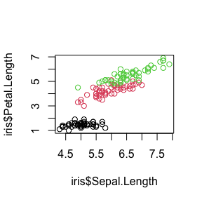

```r
plot(iris$Sepal.Length, iris$Petal.Length, col=iris$Species)
```

### Example 3: 简单做下相关性分析

Pearson 相关系数：

$$\rho _{X,Y}=\frac { {\rm cov}
(X,Y)}{\sigma_{X}\sigma_{Y}}$$

```r
cor.test(iris$Sepal.Length, iris$Petal.Length, method="pearson")
```

```
##
##  Pearson's product-moment correlation
##
## data:  iris$Sepal.Length and iris$Petal.Length
## t = 21.646, df = 148, p-value < 2.2e-16
## alternative hypothesis: true correlation is not equal to 0
## 95 percent confidence interval:
##  0.8270363 0.9055080
## sample estimates:
##       cor
## 0.8717538
```

Spearman 相关系数：

$${\displaystyle r_{s}=\rho
_{\operatorname {R} (X),\operatorname {R} (Y)}={\frac {\operatorname
{cov} (\operatorname {R} (X),\operatorname {R} (Y))}{\sigma
_{\operatorname {R} (X)}\sigma _{\operatorname {R} (Y)}}},}$$

```r
cor.test(iris$Sepal.Length, iris$Petal.Length, method="spearman")
```

```
##
##  Spearman's rank correlation rho
##
## data:  iris$Sepal.Length and iris$Petal.Length
## S = 66429, p-value < 2.2e-16
## alternative hypothesis: true rho is not equal to 0
## sample estimates:
##       rho
## 0.8818981
```

Kendall 相关系数：

$${\displaystyle \tau ={\frac
{({\text{number of concordant pairs}})-({\text{number of discordant
pairs}})}{({\text{number of pairs}})}}=1-{\frac {2({\text{number of
discordant pairs}})}{n \choose 2}}.}$$

```r
cor.test(iris$Sepal.Length, iris$Petal.Length, method="kendall")
```

```
##
##  Kendall's rank correlation tau
##
## data:  iris$Sepal.Length and iris$Petal.Length
## z = 12.647, p-value < 2.2e-16
## alternative hypothesis: true tau is not equal to 0
## sample estimates:
##       tau
## 0.7185159
```

可以看到，几种相关系数都显示 `Sepal.Length` 和 `Petal.Length`强烈相关。

# HW1

### Question

> 利用逆变换法复现函数 sample 的部分功能（`replace = TRUE`）

### Answer

```r
my.sample <- function(x, size, prob = NULL) {
    n <- length(x)

    if (is.null(prob)) {
        prob <- rep(1/n, n)
    }

    cp <- cumsum(prob)

    u <- runif(size)

    ret <- x[findInterval(u, cp) + 1]

    return(ret)
}
```

试一下

```r
my.sample(1:3, 20)
```

```
##  [1] 3 3 2 3 3 2 2 2 2 3 1 1 2 2 1 2 2 2 3 2
```

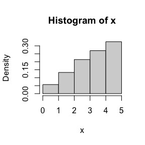

```r
x <- my.sample(1:5, 1000, prob=c(1,2,3,4,5) / 15)
hist(x, prob = TRUE, breaks = 0:5)
```

### Question

3.2. The standard Laplace distribution has density $f(x)=\frac{1}{2}e^{-|x|}, x ∈ \mathbf{R}$. Use the inverse transform method to generate a random sample of size 1000 from this distribution. Use one of the methods shown in this chapter to compare the generated sample to the target distribution.

### Answer

累积分布函数为 $F(x)=\int^x_{-\inf} f(x) \mathrm{d}x$，$x<0$ 时，$F(x)=e^x/2$， $x>0$ 时，$F(x)=1-e^{-x}/2$. 其反函数为，$u<1/2$ 时， $F^{-1}(u)=ln(2u)$， $u>1/2$ 时，$F^{-1}(u)=-ln[2(1-u)]$。即可利用 inverse transform method 生成随机数。

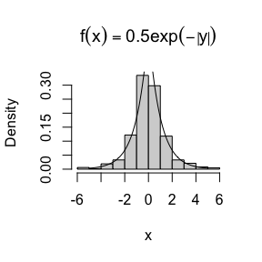

```r
n <- 1000
u <- runif(n)
x <- numeric(length(u))
x[u < 0.5] <- log(2*u[u < 0.5])
x[u > 0.5] <- -log(2*(1-u[u > 0.5]))

hist(x, prob = TRUE, main = expression(f(x)==0.5*exp(-abs(y))))
y <- seq(-5, 5, .1)
lines(y, 0.5*exp(-abs(y)))
```

### Question

3.7. Write a function to generate a random sample of size n from the Beta(a, b) distribution by the acceptance-rejection method. Generate a random sample of size 1000 from the Beta(3,2) distribution. Graph the histogram of the sample with the theoretical Beta(3,2) density superimposed.

### Answer

求导代入计算可得 Beta(a, b) 分布 pdf 的峰值，便可使用 acceptance-rejection algorithm 生成样本。

```r
my.beta <- function(a, b, x) {
    return(gamma(a + b) / gamma(a) / gamma(b) * x^(a-1) * (1-x)^(b - 1))
}

my.genbeta <- function(a, b, n) {
    k <- 0
    y <- numeric(n)
    max.beta <- ((a - 1) / (a + b - 2)) ^ (a - 1) * ((b - 1) / (a + b - 2)) ^ (b - 1) * gamma(a + b) / gamma(a) / gamma(b)

    while (k < n) {
        u <- runif(1)
        x <- runif(1)
        if (my.beta(a, b, x) / max.beta > u) {
            k <- k + 1
            y[k] <- x
        }
    }

    return(y)
}
```

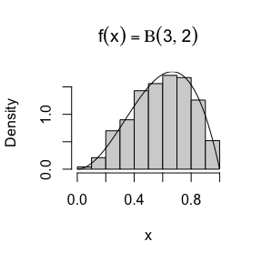

```r
x = my.genbeta(3, 2, 1000)
hist(x, prob = TRUE, main = expression(f(x)==Beta(3,2)))
y <- seq(0, 1, .01)
lines(y, my.beta(3, 2, y))
```

### Question

3.9. The rescaled Epanechnikov kernel [85] is a symmetric density function

$$f_e(x)=\frac{3}{4}(1-x^2), |x| \le 1$$

Devroye and Gy¨orfi [71, p. 236] give the following algorithm for simulation from this distribution. Generate iid U1, U2, U3 ∼ Uniform(−1, 1). If |U3| ≥ |U2| and |U3|≥|U1|, deliver U2; otherwise deliver U3. Write a function to generate random variates from fe, and construct the histogram density estimate of a large simulated random sample.

```r
genfe <- function(n) {
    u1 <- runif(n) * 2 - 1
    u2 <- runif(n) * 2 - 1
    u3 <- runif(n) * 2 - 1

    y <- u3
    cond <- (abs(u3) >= abs(u2)) & (abs(u3) >= abs(u1))
    y[cond] <- u2[cond]

    return(y)
}
```

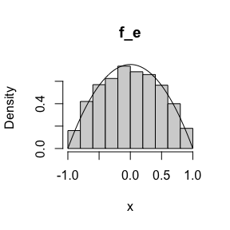

```r
x <- genfe(1000)
hist(x, prob = TRUE, main = "f_e")
y <- seq(-1, 1, .01)
lines(y, 0.75*(1-y^2))
```

### Question

3.10. Prove that the algorithm given in Exercise 3.9 generates variates from the density fe.

### Answer

这个算法实际上是，先生成了三个均匀分布 U(0,1) 的变量，然后取其中不是最大值的两个生成混合分布， 最后以一半的概率将其变为负数。可以先计算第二步后的累积分布函数，要使 $X < t$，要么至少有两个变量小于 t， $p1=C^2_3 t^2(1-t) + C^3_3t^3=t^2(3-2t)$，要么只有一个变量小于 t 且正好取到了该变量， $p2=C_3^1 t(1-t)^2*1/2=3/2t(1-t)^2$。两者相加并求导可得 pdf $f(x)=3/2(1-t^2)$。最后 一步则相当于把该 pdf 对 y 轴做了一个对称且重新归一化，最终 pdf 即为

$$f_e(x)=\frac{3}{4}(1-x^2), |x| \le 1$$

# HW2

### Question

- Proof that what value ρ = l/d should take to minimize the asymptotic variance of $\hat{\pi}$? (m ∼ B(n,p), using δ method)
- Take three different values of ρ (0 ≤ ρ ≤ 1, including ρmin) and use Monte Carlo simulation to verify your answer. (n = 1e6, Number of repeated simulations K = 100)

### Answer

$\hat{\pi}=\frac{2l}{d\hat{p}}$，其中 $\hat{p}=m/n$ 是 p 的估计值， 其方差为 $Var(\hat{p})=p(1-p)/n$，而 $p=\frac{2l}{d\pi}$. 所以

$$Var(\frac{1}{\hat{\pi}})=\frac{d}{2l}
p(1-p)/n = \frac{1-p}{n\pi}$$

要使 $\hat{\pi}$ 方差最小，应使 $1/\hat{\pi}$ 方差最小，p 应接近 1， $\rho=l/d$ 应接近 $\pi/2$。

```r
buffon <- function(rho) {
    n <- 1e6
    l <- 1
    d <- l/rho

    X <- runif(n,0,d/2)
    Y <- runif(n,0,pi/2)
    pihat <- 2*l/d/mean(l/2*sin(Y)>X)
    return(pihat)
}
```

```r
pihat1 <- replicate(100, buffon(1/3))
pihat2 <- replicate(100, buffon(2/3))
pihat3 <- replicate(100, buffon(1))
c(sd(pihat1), sd(pihat2), sd(pihat3))
```

```
## [1] 0.006388869 0.003702363 0.002649388
```

确实是取值越接近 $\pi/2$ 方差越小。

### Question

5.6. In Example 5.7 the control variate approach was illustrated for Monte Carlo integration of

$$\theta = \int_0^1 e^x dx$$

Now consider the antithetic variate approach. Compute $Cov(e^U , e^{1−U})$ and $Var(e^U + e^{1−U})$, where U ∼ Uniform(0,1). What is the percent reduction in variance of $\hat{\theta}$ that can be achieved using antithetic variates (compared with simple MC)?

### Answer

设 $e^U, e^{1-U}$ 分别为 $U_1, U_2$。 $Cov(U_1, U_2)$ 和 $Var(U_1 + U_2)$ 分别为

```r
u <- runif(1000)
u1 <- exp(u)
u2 <- exp(1-u)

cov.u1.u2 = cov(u1, u2)
var.u1.add.u2 = var(u1 + u2)

c(cov.u1.u2, var.u1.add.u2)
```

```
## [1] -0.23442039  0.01549646
```

$$Var(U_1) = Var(U_2) = (Var(U_1 + U_2) - 2Cov(U_1, U_2)) / 2$$

```r
var.u1 = 0.5 * var.u1.add.u2 - cov.u1.u2
```

方差减少百分比为

$$1 - Var((U_1 + U_2) / 2) / Var(U_1) = 0.5 - 0.5 Cov(U_1, U_2) / Var(U_1)$$

```r
0.5 - 0.5 * cov.u1.u2 / var.u1
```

```
## [1] 0.9840024
```

### Question

5.7. Refer to Exercise 5.6. Use a Monte Carlo simulation to estimate θ by the antithetic variate approach and by the simple Monte Carlo method. Compute an empirical estimate of the percent reduction in variance using the antithetic variate. Compare the result with the theoretical value from Exercise 5.6.

### Answer

两种方法估计 $\theta$

```r
# antithetic variate approach
u <- runif(1000)
u1 <- exp(u)
u2 <- exp(1-u)

theta1 <- (u1 + u2) / 2

# simple Monte Carlo method
u <- runif(1000)
theta2 <- exp(u)

c(mean(theta1), mean(theta2))
```

```
## [1] 1.715612 1.727971
```

比较方差

```r
c(var(theta1), var(theta2), 1 - var(theta1)/var(theta2))
```

```
## [1] 0.003869731 0.247638405 0.984373461
```

和理论预言一致。

# HW3

### Question

$Var(\hat{\theta}^M)= \frac{1}{Mk} \sum_{i=1}^k \sigma_i^2+Var(\theta_I)=Var(\hat{\theta}^S)+Var(θ_I)$ , where $θ_i =E[g(U)|I =i],σ_i^2 =Var[g(U)|I =i]$ and $I$ takes uniform distribution over $\{1, . . . , k\}$. Proof that if $g$ is a continuous function over $(a, b)$, then $Var(\hat{\theta}^S )/Var(\hat{\theta}^M ) → 0$ as $b_i − a_i → 0$ for all $i = 1,...,k$.

### Answer

$b_i-a_i\rightarrow 0$ 时，

$$Var(\hat{\theta}^S)=\frac{1}{Mk}\sum_{i=1}^k \sigma_i^2
\rightarrow
\frac{1}{Mk}\sum_{i=1}^k g'^2(a_i) \frac{(b_i-a_i)^2}{12}
\rightarrow 0$$

而 $a_i$ $b_i$ 的选取不影响 $Var(\hat{\theta}^M )$

$$Var(\hat{\theta}^S )/Var(\hat{\theta}^M ) → 0$$

### Question

5.13. Find two importance functions $f_1$ and $f_2$ that are supported on $(1, ∞)$ and are ‘close’ to

$$g(x)=\frac{x^2}{\sqrt{2\pi}} e^{-x^2/2}, x>1$$

Which of your two importance functions should produce the smaller variance in estimating

$$\int_1^\infty \frac{x^2}{\sqrt{2\pi}} e^{-x^2/2} \mathrm{d} x$$

by importance sampling? Explain.

### Answer

两个重要性函数，$f_1(x)=\exp(-x^2/2)/\sqrt{2\pi}$，$f_2(x)=1/x^2$。

理论方差分别为

$$\int_{1}^{+\infty} \frac{g^2(x)}{f_1(x)} \mathrm{d}x - \theta^2
\approx 1.44 - \theta^2$$

$$\int_{1}^{+\infty} \frac{g^2(x)}{f_2(x)} \mathrm{d}x - \theta^2
\approx 0.25 - \theta^2$$

使用 $f_2$ 方差应该更小。

### Question

5.14. Obtain a Monte Carlo estimate of

$$\int_1^\infty \frac{x^2}{\sqrt{2\pi}} e^{-x^2/2} \mathrm{d} x$$

by importance sampling.

### Answer

使用重要性函数 $f(x)=1/x^2$ 进行采样

```r
u <- runif(10000)
x <- 1/(1-u)
theta <- x^2 /sqrt(2*pi) * exp(-x^2/2) / (1/x^2)

mean(theta)
```

```
## [1] 0.4013947
```

### Question

5.15. Obtain the stratified importance sampling estimate in Example 5.13 and compare it with the result of Example 5.10.

### Answer

```r
M <- 10000; k <- 5
r <- M/k
theta <- numeric(M)
g <- function(x) exp(-x - log(1+x^2)) * (x > 0) * (x < 1)
f <- function(x) exp(-x) / (1 - exp(-1))

for (j in 1:k) {
    u <- runif(r, (j-1)/k, j/k)
    x <- - log(1 - u * (1 - exp(-1)))
    theta[(r*(j-1)+1):(r*j)] <- g(x)/f(x)
}

mean(theta)
```

```
## [1] 0.5247325
```

与例 5.10 的结果接近。

### Question

6.5. Suppose a $95\%$ symmetric $t$-interval is applied to estimate a mean, but the sample data are non-normal. Then the probability that the confidence interval covers the mean is not necessarily equal to $0.95$. Use a Monte Carlo experiment to estimate the coverage probability of the $t$-interval for random samples of $χ^2(2)$ data with sample size $n = 20$. Compare your $t$-interval results with the simulation results in Example 6.4. (The $t$-interval should be more robust to departures from normality than the interval for variance.)

### Answer

```r
M <- 10000
N <- 0

n <- 20
alpha <- 0.05

for (i in 1:M) {
    sample <- rchisq(n, df=2)
    upper <- mean(sample) + sd(sample)/sqrt(n)*qt(1-alpha/2, df=n-1)
    lower <- mean(sample) - sd(sample)/sqrt(n)*qt(1-alpha/2, df=n-1)

    if (2 < upper && 2 > lower) N = N + 1
}

N/M
```

```
## [1] 0.9179
```

相比例 6.4，概率要小于 $95\%$。

### Question

6.A. Use Monte Carlo simulation to investigate whether the empirical Type I error rate of the t-test is approximately equal to the nominal significance level α, when the sampled population is non-normal. The t-test is robust to mild departures from normality. Discuss the simulation results for the cases where the sampled population is (i) $χ^2(1)$, (ii) Uniform(0,2), and (iii) Exponential(rate=1). In each case, test $H_0 : µ = µ_0$ vs $H_0 : µ \neq µ0$, where µ0 is the mean of $χ_2(1)$, Uniform(0,2), and Exponential(1), respectively.

### Answer

1. 卡方分布 $χ_2(1)$

```r
M <- 10000
n <- 20

p.val <- numeric(M)

for (i in 1:M) {
    sample <- rchisq(n, df=1)
    mu <- 1
    t <- (mean(sample) - mu) / (sd(sample) / sqrt(n))
    p.val[i] <- 2*(1-pt(abs(t), n-1))
}

mean(p.val<=0.05)
```

```
## [1] 0.1005
```

2. 均匀分布 Uniform(0,2)

```r
M <- 10000
n <- 20

p.val <- numeric(M)

for (i in 1:M) {
    sample <- runif(n, 0, 2)
    mu <- 1
    t <- (mean(sample) - mu) / (sd(sample) / sqrt(n))
    p.val[i] <- 2*(1-pt(abs(t), n-1))
}

mean(p.val<=0.05)
```

```
## [1] 0.0504
```

3. 指数分布 Exponential(1)

```r
M <- 10000
n <- 20

p.val <- numeric(M)

for (i in 1:M) {
    sample <- rexp(n, 1)
    mu <- 1
    t <- (mean(sample) - mu) / (sd(sample) / sqrt(n))
    p.val[i] <- 2*(1-pt(abs(t), n-1))
}

mean(p.val<=0.05)
```

```
## [1] 0.0773
```

i 和 iii 情形第一类错误率稍微偏大，ii 情形第一类错误率和显著水平 $\alpha$ 很接近。

# HW4

### Question

考虑 $m=1000$ 个假设，其中前 $95%$ 个原假设成立，后 $5%$ 个对立假设成立。 在原假设下 p 值服从 $U(0,1)$ 分布，在对立假设下 p 值服从 $Beta(0.1, 1)$ 分布。 将 Bonferroni 校正与 B-H 校正应用于生成的 $m$ 个 p 值，得到校正后的 p 值， 与 $\alpha=0.1$ 比较确定是否拒绝原假设。基于 $M=1000$ 次模拟， 估计 FWER, FDR, TPR, 输出到表格中。

### Answer

```r
M <- 1000
m <- 1000

alpha <- 0.1

FWER.bonferroni <- numeric(M)
FDR.bonferroni <- numeric(M)
TPR.bonferroni <- numeric(M)

FWER.BH <- numeric(M)
FDR.BH <- numeric(M)
TPR.BH <- numeric(M)


for (i in 1:M) {
    p <- numeric(m)
    null.is.true <- logical(m)
    p[1:(0.95*m)] <- runif(0.95*m)
    null.is.true[1:(0.95*m)] <- TRUE
    p[(0.95*m+1):m] <- rbeta(0.05*m, 0.1, 1)

    p.bonferroni <- p.adjust(p, method = "bonferroni")
    p.BH <- p.adjust(p, method = "BH")

    FWER.bonferroni[i] <- any(p.bonferroni < alpha & null.is.true)
    FDR.bonferroni[i] <- sum(p.bonferroni < alpha & null.is.true) / sum(p.bonferroni < alpha)
    TPR.bonferroni[i] <- sum(p.bonferroni < alpha & !null.is.true) / sum(!null.is.true)

    FWER.BH[i] <- any(p.BH < alpha & null.is.true)
    FDR.BH[i] <- sum(p.BH < alpha & null.is.true) / sum(p.BH < alpha)
    TPR.BH[i] <- sum(p.BH < alpha & !null.is.true) / sum(!null.is.true)
}

tb <- matrix(c(mean(FWER.bonferroni),mean(FDR.bonferroni),mean(TPR.bonferroni),
               mean(FWER.BH),mean(FDR.BH),mean(TPR.BH)),
             nrow = 2, ncol = 3, byrow = TRUE,
             dimnames = list(c("bonferroni", "BH"),
                             c("FWER", "FDR", "TPR")))

knitr::kable(tb)
```

|  | FWER | FDR | TPR |
| --- | --- | --- | --- |
| bonferroni | 0.072 | 0.0038189 | 0.39892 |
| BH | 0.927 | 0.0951432 | 0.56444 |

### Question

Suppose the population has the exponential distribution with rate $\lambda$, then the MLE of $\lambda$ is $\hat\lambda=1/\bar X$, where $\bar X$ is the sample mean. It can be derived that the expectation of $\hat\lambda$ is $\lambda n/(n-1)$, so that the estimation bias is $\lambda/(n-1)$. The standard error $\hat\lambda$ is $\lambda n/[(n-1)\sqrt{n-2}]$. Conduct a simulation study to verify the performance of the bootstrap method. + The true value of $\lambda=2$. + The sample size $n=5,10,20$. + The number of bootstrap replicates $B = 1000$. + The simulations are repeated for $m=1000$ times. + Compare the mean bootstrap bias and bootstrap standard error with the theoretical ones. Comment on the results.

### Answer

```r
library(boot)
B <- 1000
m <- 1000

b.lambda <- function (x, i) 1 / mean(x[i])

tb <- matrix(numeric(12),
             nrow = 3, ncol = 4, byrow = TRUE,
             dimnames = list(c("n=5", "n=10", "n=20"),
                             c("bias", "se", "theoretical bias", "theoretical se")))

for (n in c(5, 10, 20)) {
    row <- stringr::str_c("n=", n)
    tb[row, "theoretical bias"] <- 2 / (n-1)
    tb[row, "theoretical se"] <- 2*n / (n-1) / sqrt(n-2)

    for (i in 1:m) {
        s <- rexp(n, 2)
        result <- boot(s, b.lambda, B)
        tb[row, "bias"] = tb[row, "bias"] + mean(result$t) - result$t0
        tb[row, "se"] = tb[row, "se"] + sd(result$t)
    }

    tb[row, "bias"] = tb[row, "bias"] / m
    tb[row, "se"] = tb[row, "se"] / m
}


knitr::kable(tb)
```

|  | bias | se | theoretical bias | theoretical se |
| --- | --- | --- | --- | --- |
| n=5 | 0.5657046 | 2.3957837 | 0.5000000 | 1.4433757 |
| n=10 | 0.2222619 | 0.8350992 | 0.2222222 | 0.7856742 |
| n=20 | 0.1051041 | 0.5030343 | 0.1052632 | 0.4962153 |

bootstrap 的 bias 和 se 和理论值吻合较好，特别是 n 较大时。

### Question

Obtain a bootstrap t confidence interval estimate for the correlation statistic in Example 7.2 (law data in bootstrap).

### Answer

```r
law <- cbind(
    LSAT = c(576, 635, 558, 578, 666, 580, 555, 661, 651, 605, 653, 575, 545, 572, 594),
    GPA = c(339, 330, 281, 303, 344, 307, 300, 343, 336, 313, 312, 274, 276, 288, 296)
)

r_ <- function(x, i) cor(x[i,1], x[i,2])
r <- function(x, i) {
    b <- boot(x[i,], r_, 100)
    return(c(cor(x[i,1], x[i,2]), var(b$t)))
}

obj <- boot(law, r, 2000)

boot.ci(obj, type="stud")
```

```
## BOOTSTRAP CONFIDENCE INTERVAL CALCULATIONS
## Based on 2000 bootstrap replicates
##
## CALL :
## boot.ci(boot.out = obj, type = "stud")
##
## Intervals :
## Level    Studentized
## 95%   (-0.3976,  1.0077 )
## Calculations and Intervals on Original Scale
```

# HW5

### Question

7.5. Refer to Exercise 7.4. Compute 95% bootstrap confidence intervals for the mean time between failures 1/λ by the standard normal, basic, percentile, and BCa methods. Compare the intervals and explain why they may differ.

### Answer

`boot.ci` 默认会计算全部四种算法的 $95\%$ 置信区间，直接调用即可：

```r
library(boot)

b.mean <- function (x, i) return(mean(x[i]))
obj <- boot(aircondit$hours, b.mean, 2000)
boot.ci(obj)
```

```
## BOOTSTRAP CONFIDENCE INTERVAL CALCULATIONS
## Based on 2000 bootstrap replicates
##
## CALL :
## boot.ci(boot.out = obj)
##
## Intervals :
## Level      Normal              Basic
## 95%   ( 33.4, 181.0 )   ( 20.0, 169.5 )
##
## Level     Percentile            BCa
## 95%   ( 46.7, 196.2 )   ( 56.4, 218.4 )
## Calculations and Intervals on Original Scale
## Some BCa intervals may be unstable
```

几种算法结果不同，因为他们各自基于不同的假设。

### Question

7.8 Refer to Exercise 7.7. Obtain the jackknife estimates of bias and standard error of $\hat{\theta}$

### Answer

```r
library(bootstrap)
b.theta <- function(x, i) {
    lambdas <- eigen(cor(x[i,]))$values
    return(lambdas[1] / sum(lambdas))
}

n <- 88

theta.hat <- b.theta(scor, 1:n)
theta.jack <- numeric(n)

for(i in 1:n){
    theta.jack[i] <- b.theta(scor, (1:n)[-i])
}

bias.jack <- (n-1)*(mean(theta.jack)-theta.hat)
se.jack <- sqrt((n-1)*mean((theta.jack-theta.hat)^2))

c(bias.jack=bias.jack, se.jack=se.jack)
```

```
##     bias.jack       se.jack
## -0.0003778535  0.0446668576
```

### Question

7.11. In Example 7.18, leave-one-out (n-fold) cross validation was used to select the best fitting model. Use leave-two-out cross validation to compare the models.

### Answer

```r
library(DAAG)
attach(ironslag)

n <- length(magnetic) # in DAAG ironslag
e1 <- e2 <- e3 <- e4 <- numeric(n*(n-1)) # n choose 2 error pair, 2*C_n^2


# fit models on leave-two-out samples
i <- 1 # indice of e_i
for (k in 2:n) {
    for (l in 1:(k-1)) {
        y <- magnetic[-k][-l]
        x <- chemical[-k][-l]

        J1 <- lm(y ~ x)
        yhat1 <- J1$coef[1] + J1$coef[2] * chemical[k]
        e1[i] <- magnetic[k] - yhat1
        yhat1 <- J1$coef[1] + J1$coef[2] * chemical[l]
        e1[i+1] <- magnetic[l] - yhat1

        J2 <- lm(y ~ x + I(x^2))
        yhat2 <- J2$coef[1] + J2$coef[2] * chemical[k] + J2$coef[3] * chemical[k]^2
        e2[i] <- magnetic[k] - yhat2
        yhat2 <- J2$coef[1] + J2$coef[2] * chemical[l] + J2$coef[3] * chemical[l]^2
        e2[i+1] <- magnetic[l] - yhat2

        J3 <- lm(log(y) ~ x)
        logyhat3 <- J3$coef[1] + J3$coef[2] * chemical[k]
        yhat3 <- exp(logyhat3)
        e3[i] <- magnetic[k] - yhat3
        logyhat3 <- J3$coef[1] + J3$coef[2] * chemical[l]
        yhat3 <- exp(logyhat3)
        e3[i+1] <- magnetic[l] - yhat3

        J4 <- lm(log(y) ~ log(x))
        logyhat4 <- J4$coef[1] + J4$coef[2] * log(chemical[k])
        yhat4 <- exp(logyhat4)
        e4[i] <- magnetic[k] - yhat4
        logyhat4 <- J4$coef[1] + J4$coef[2] * log(chemical[l])
        yhat4 <- exp(logyhat4)
        e4[i+1] <- magnetic[l] - yhat4

        i = i + 2
    }
}

c(mean(e1^2), mean(e2^2), mean(e3^2), mean(e4^2))
```

```
## [1] 19.57227 17.87018 18.45491 20.46718
```

结果和 leave-one-out 差不多，也是 Model 2 最好。

# HW6

### Question

Proof the Stationarity of Metropolis-Hastings sampler Algorithm in continuous situation.

### Answer

Stationarity: $K(s, r) f(s) = K(r, s) f(r)$

等式左边等于：

$$\left\{\alpha(s, r) g(r|s) + I(s=r) \left[1 - \int \alpha(s, r)
g(r|s)\right]\right\} f(s) \\
= \alpha(s, r) g(r|s) f(s) + I(s=r) \left[1 - \int \alpha(s, r)
g(r|s)\right] f(s)$$

$f(r)g(s|r) > f(s)g(r|s)$ 时，$\alpha(s, r) = 1$。 左边等于：

$$g(r|s) f(s) + I(s=r) \left[1 - \int \alpha(s, r) g(r|s)\right] f(s)$$

$f(r)g(s|r) \leq f(s)g(r|s)$ 时，$\alpha(s, r) = \frac{f(r)g(s|r)} {f(s)g(r|s)}$。左边等于：

$$g(s|r) f(r) + I(s=r) \left[1 - \int \alpha(s, r) g(r|s)\right] f(s)$$

等式右边同理有以上结果，式子第一项相等，而式子第二项注意到乘了 $I(s=r)$， 所以第二项中 $s$ 和 $r$ 可以任意代换所以也相等。

所以 Stationarity 成立。

### Question

8.1. Implement the two-sample Cramer-von Mises test for equal distributions as a permutation test. Apply the test to the data in Examples 8.1 and 8.2.

### Answer

实现两样本 Cramer-von Mises 检验的函数：

```r
library(boot)

boot.cvm <- function(z, ix, sizes) {
    n <- sizes[1]; m <- sizes[2]; nm <- n + m
    z <- z[ix]

    xs <- z[1:n]; ys <- z[(n+1):nm]
    F <- ecdf(xs)
    G <- ecdf(ys)

    m*n/(m+n)^2 * ( sum((F(xs) - G(xs))^2) + sum((F(ys) - G(ys))^2) )
}

perm.cvm <- function(xs, ys) {
    boot.obj <- boot(data = c(xs, ys), statistic = boot.cvm, R = 999,
                     sim = "permutation", sizes = c(length(xs), length(ys)))

    ts <- c(boot.obj$t0,boot.obj$t)
    mean(ts>=ts[1])
}
```

对例 8.1 和 8.2 的数据应用：

```r
attach(chickwts)
x <- sort(as.vector(weight[feed == "soybean"]))
y <- sort(as.vector(weight[feed == "linseed"]))
detach(chickwts)

perm.cvm(x, y)
```

```
## [1] 0.416
```

p 值较大，不能拒绝两样本无显著差别的原假设。

### Question

8.3. The Count 5 test for equal variances in Section 6.4 is based on the maximum number of extreme points. Example 6.15 shows that the Count 5 criterion is not applicable for unequal sample sizes. Implement a permutation test for equal variance based on the maximum number of extreme points that applies when sample sizes are not necessarily equal.

### Answer

```r
count5test <- function(x, y) {
    X <- x - mean(x)
    Y <- y - mean(y)
    outx <- sum(X > max(Y)) + sum(X < min(Y))
    outy <- sum(Y > max(X)) + sum(Y < min(X))

    return(max(c(outx, outy)))
}

boot.c5 <- function(z, ix, sizes) {
    n <- sizes[1]; m <- sizes[2]; nm <- n + m
    z = z[ix]

    count5test(z[1:n], z[(n+1):nm])
}

perm.c5 <- function(xs, ys) {


    boot.obj <- boot(data = c(xs, ys), statistic = boot.c5, R = 999,
                     sim = "permutation", sizes = c(length(xs), length(ys)))

    ts <- c(boot.obj$t0,boot.obj$t)
    mean(ts>=ts[1])
}
```

试一下：

```r
x <- rnorm(100, 0, 1)
y <- rnorm(20, 0, 1)
perm.c5(x, y)
```

```
## [1] 0.667
```

p 较大，不能拒绝原假设，符合预期。

```r
x <- rnorm(30, 0, 1)
y <- rnorm(70, 0, 2)
perm.c5(x, y)
```

```
## [1] 0.026
```

p 很小，拒绝原假设，符合预期。

# HW7

### Question

Consider a model $P(Y = 1 | X_1,X_2,X_3) = \frac{\mathrm{exp}(a+b_1X_1+b_2X_2+b_3X_3)} {1+\mathrm{exp}(a+b_1 X_1 +b_2 X_2 +b_3 X_3 )}$, where $X_1 ∼ P(1)$, $X_2 ∼ Exp(1)$ and $X_3 ∼ B(1, 0.5)$.

- Design a function that takes as input values $N$, $b_1$, $b_2$, $b_3$ and $f_0$, and produces the output $a$.
- Call this function, input values are $N = 10^6$ , $b_1 = 0$, $b_2 = 1$, $b_3 = −1$, $f_0 = 0.1, 0.01, 0.001, 0.0001$.
- Plot $−\mathrm{log}f_0$ vs $a$.

### Answer

求 a 的函数为：

```r
produce.a <- function(N, b1, b2, b3, f0) {
    X1 <- rpois(N, 1)
    X2 <- rexp(N, 1)
    X3 <- rbinom(N, 1, 0.5)

    g <- function(a) {
        tmp <- exp(-a - b1*X1 - b2*X2 - b3*X3)

        mean(1/(1+tmp)) - f0
    }

    res <- uniroot(g, c(-100, 0))
    res$root
}
```

调用函数：

```r
f0s = c(1e-1, 1e-2, 1e-3, 1e-4)
as = sapply(f0s, function (f0) produce.a(1e6, 0, 1, -1, f0))
as
```

```
## [1]  -3.170631  -6.079317  -8.736401 -11.257403
```

画图：

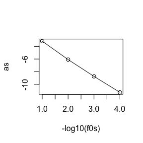

```r
plot(-log10(f0s), as)
lines(-log10(f0s), as)
```

### Question

9.4. Implement a random walk Metropolis sampler for generating the standard Laplace distribution (see Exercise 3.2). For the increment, simulate from a normal distribution. Compare the chains generated when different variances are used for the proposal distribution. Also, compute the acceptance rates of each chain.

### Answer

```r
rwMC <- function (N, f, rwsd, x0) {
    # proposal distribution for random walk
    rg <- function(xt) rnorm(1, xt, rwsd)
    dg <- function(xt, x) dnorm(x, xt, rwsd)

    # chain
    xs <- numeric(N)
    xs[1] <- x0

    # acceptance rate
    ac <- numeric(N)
    ac[1] <- 1

    for (i in 1:(N-1)) {
        Y <- rg(xs[i])
        U <- runif(1)

        if (U <= f(Y)*dg(Y, xs[i])/f(xs[i])/dg(xs[i], Y)) {
            xs[i+1] = Y
            ac[i+1] = 1
        } else {
            xs[i+1] = xs[i]
        }
    }

    list(chain=xs, ac=mean(ac))
}
```

Laplace 分布 pdf 为 $f(x)=\frac{1}{2}e^{- |x|}$。

初始值设为 5，分别使用标准差 1, 0.5, 0.1 的结果：

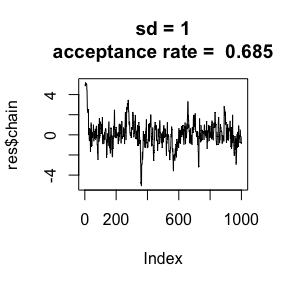

```r
f <- function (x) 1/2*exp(-abs(x))
N <- 1e3

res <- rwMC(N, f, 1, 5)
plot(res$chain, type="l", main=paste("sd = 1\nacceptance rate = ", res$ac))
```

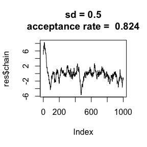

```r
res <- rwMC(N, f, 0.5, 5)
plot(res$chain, type="l", main=paste("sd = 0.5\nacceptance rate = ", res$ac))
```

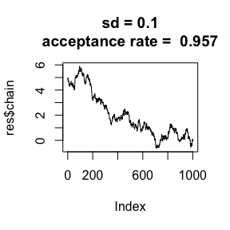

```r
res <- rwMC(N, f, 0.1, 5)
plot(res$chain, type="l", main=paste("sd = 0.1\nacceptance rate = ", res$ac))
```

标准差越小，接受率越大，但到达稳态时间也更长。

### Question

9.7. Implement a Gibbs sampler to generate a bivariate normal chain (Xt, Yt) with zero means, unit standard deviations, and correlation 0.9. Plot the generated sample after discarding a suitable burn-in sample. Fit a simple linear regression model Y = β0 + β1X to the sample and check the residuals of the model for normality and constant variance.

### Answer

```r
mc.binorm <- function(N) {
    xs <- numeric(N)
    ys <- numeric(N)

    for (i in 1:(N-1)) {
        xs[i+1] <- rnorm(1, 0.9*ys[i], 1-0.9^2)
        ys[i+1] <- rnorm(1, 0.9*xs[i+1], 1-0.9^2)
    }

    list(x = xs, y = ys)
}

res <- mc.binorm(1e4)
# discard burn-in
res$x <- res$x[1e3:1e4]
res$y <- res$y[1e3:1e4]
```

绘制散点图：

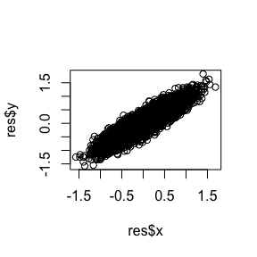

```r
plot(res$x, res$y)
```

线性回归:

```r
fit <- lm(y ~ x, res)
summary(fit)
```

```
##
## Call:
## lm(formula = y ~ x, data = res)
##
## Residuals:
##     Min      1Q  Median      3Q     Max
## -0.7120 -0.1303 -0.0009  0.1287  0.7085
##
## Coefficients:
##             Estimate Std. Error t value Pr(>|t|)
## (Intercept) 0.002770   0.002025   1.368    0.171
## x           0.899929   0.004631 194.334   <2e-16 ***
## ---
## Signif. codes:  0 '***' 0.001 '**' 0.01 '*' 0.05 '.' 0.1 ' ' 1
##
## Residual standard error: 0.1922 on 8999 degrees of freedom
## Multiple R-squared:  0.8076, Adjusted R-squared:  0.8075
## F-statistic: 3.777e+04 on 1 and 8999 DF,  p-value: < 2.2e-16
```

检验残差的正态性：

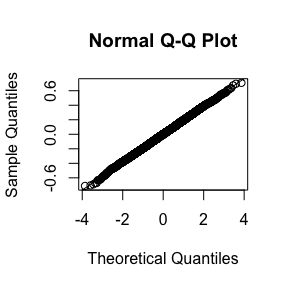

```r
qqnorm(fit$residuals)
qqline(fit$residuals)
```

QQ 图显示与正态非常接近。

检验方差是否恒定：

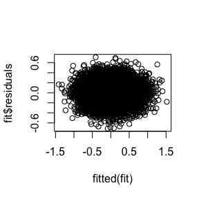

```r
plot(fitted(fit), fit$residuals)
```

方差恒定。

### Question

9.10. Refer to Example 9.1. Use the Gelman-Rubin method to monitor convergence of the chain, and run the chain until the chain has converged approximately to the target distribution according to $\hat{R} < 1.2$. (See Exercise 9.9.) Also use the coda package to check for convergence of the chain by the Gelman-Rubin method. Hints: See the help topics for the coda functions gelman.diag, gelman.plot, as.mcmc, and mcmc.list

### Answer

计算 $\hat{R}$:

```r
R.hat <- function (chains) {
    Wn <- mean(apply(chains, 2, var))
    var.hat <- var(c(chains))

    var.hat / Wn
}
```

同时生成 10 条马尔可夫链，直到 $\hat{R} < 1.2$：

```r
f <- function(x, sigma) {
    if (any(x < 0)) return (0)
    stopifnot(sigma > 0)
    return((x / sigma^2) * exp(-x^2 / (2*sigma^2)))
}


m <- 1e4
sigma <- 4
chains <- matrix(0, ncol=10, nrow=m)
chains[1,] <- rchisq(10, df=1)
k <- 0
u <- matrix(runif(m*10), ncol=10, nrow=m)

for (i in 2:m) {
    for (j in 1:10) {
        xt <- chains[i-1, j]
        y <- rchisq(1, df = xt)
        num <- f(y, sigma) * dchisq(xt, df = y)
        den <- f(xt, sigma) * dchisq(y, df = xt)
        if (u[i, j] <= num/den) chains[i, j] <- y else {
            chains[i, j] <- xt
            k <- k+1 #y is rejected
        }
    }

    if (R.hat(chains[1:i,]) < 1.2) {
        chains = chains[1:i,]
        break
    }
}
```

计算 $\hat{R}$:

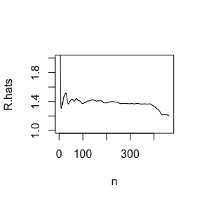

```r
n <- 2:nrow(chains)
R.hats <- lapply(n, function (n) R.hat(chains[1:n,]))

plot(n, R.hats, type="l", ylim=c(1,2))
```

使用 coda 分析：

```r
library(coda)

chains.coda <- do.call(mcmc.list, lapply(1:10, function (i) as.mcmc(chains[,i])))

gelman.diag(chains.coda)
```

```
## Potential scale reduction factors:
##
##      Point est. Upper C.I.
## [1,]       1.08       1.15
```

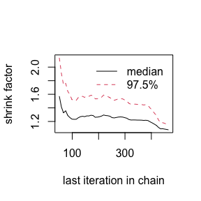

```r
gelman.plot(chains.coda)
```

# HW8

### Question

设 $X_1,...,X_n \sim Exp(\lambda)$，因为某种原因只知道 $X_i$ 在区间 $(u_i, v_i)$，其中 $u_i < v_i$ 是两个非随机的已知常数。这种数据称为区间删失数据。

1. 试分别极大化观测数据的似然函数与采用 EM 算法求解 $\lambda$ 的 MLE，证明 EM 算法收敛于观测数据， 且收敛有线性速度。
2. 设 $u_i, v_i$ 的观测值为 (11,12), (8,9), (27,28), (13,14), (16,17), (0,1), (23,24), (10,11), (24,25), (2,3)。试分别编程实现上述两种算法以得到 $\lambda$ 的 MLE 的数值解。

### Answer

观测数据的似然函数：

$$L(\lambda)=\prod_{i=1}^n P_\lambda (u_i < X_i < v_i)$$

$$I(\lambda) = \sum_{i=1}^n log \int_{u_i}^{v_i} \lambda e^{-\lambda x} dx$$

对 $\lambda$ 求导，令其为 0：

$$I'(\lambda) = \sum_{i=1}^n \frac{ \int_{u_i}^{v_i} (1 - \lambda x)
e^{-\lambda x} dx}
{\int_{u_i}^{v_i} \lambda e^{-\lambda x} dx} =
\sum_{i=1}^n \left( \frac{1}{\lambda} - E(X_i | u_i, v_i,
\lambda_t)\right) = 0$$

即

$$\lambda = \frac{n}{\sum_{i=1}^n E(X_i | u_i, v_i, \lambda)}$$

总体似然函数

$$L(\lambda | X_i) = \prod_{i=1}^n \lambda e^{-\lambda X_i}$$

$$I(\lambda | X_i) = n log(\lambda) - \lambda\sum_{i=1}^n X_i$$

E-step:

$$E[I(\lambda | X_i) | u_i, v_i] =
n log(\lambda) - \lambda\sum_{i=1}^n E(X_i | u_i, v_i)$$

M-step:

$$\lambda_{t+1} = \frac{n}{\sum_{i=1}^n E(X_i | u_i, v_i, \lambda_t)}$$

可以看到，其不动点就是极大化观测数据的似然函数的结果。

设迭代函数为

$$f(\lambda) = \frac{n}{\sum_{i=1}^n E(X_i | u_i, v_i, \lambda_t)}$$

$$\lim_{t\rightarrow \infty} \frac{\lambda_{t+1} -
\lambda_*}{\lambda_t-\lambda_*} =
f'(\lambda) = 常数$$

所以线性收敛。

```r
us <- c(11, 8, 27, 13, 16, 0, 23, 10, 24, 2)
vs <- c(12, 9, 28, 14, 17, 1, 24, 11, 25, 3)

estimate.em <- function (us, vs, max_iter) {
    l <- 1
    n <- length(us)

    for (i in 1:max_iter) {
        ex <- numeric(n)
        for (j in 1:n) {
            ex[j] <- integrate(function(x) x*dexp(x, l), us[j], vs[j])$value /
                    (pexp(vs[j], l) - pexp(us[j], l))
        }
        tmp <- n / sum(ex)

        if (abs(tmp - l) < 1e-6) {
            return(tmp)
        }

        l <- tmp
    }

    l
}

estimate.obs <- function (us, vs) {
    n <- length(us)

    logl <- function(l) {
        ret <- 0
        for (i in 1:n) {
            ret = ret + log(pexp(vs[i], l) - pexp(us[i], l))
        }
        ret
    }

    optimise(logl, c(1e-6, 1), maximum=TRUE)$maximum
}
```

```r
estimate.em(us, vs, 1e6)
```

```
## [1] 0.0719735
```

```r
estimate.obs(us, vs)
```

```
## [1] 0.07196674
```

### Question

```r
solve.game <- function(A) {
    #solve the two player zero-sum game by simplex method
    #optimize for player 1, then player 2
    #maximize v subject to ...
    #let x strategies 1:m, and put v as extra variable
    #A1, the <= constraints
    #
    min.A <- min(A)
    A <- A - min.A #so that v >= 0
    max.A <- max(A)
    A <- A / max(A)
    m <- nrow(A)
    n <- ncol(A)
    it <- n^3
    a <- c(rep(0, m), 1) #objective function
    A1 <- -cbind(t(A), rep(-1, n)) #constraints <=
    b1 <- rep(0, n)
    A3 <- t(as.matrix(c(rep(1, m), 0))) #constraints sum(x)=1
    b3 <- 1
    sx <- simplex(a=a, A1=A1, b1=b1, A3=A3, b3=b3,
    maxi=TRUE, n.iter=it)
    #the ’solution’ is [x1,x2,...,xm | value of game]
    #
    #minimize v subject to ...
    #let y strategies 1:n, with v as extra variable
    a <- c(rep(0, n), 1) #objective function
    A1 <- cbind(A, rep(-1, m)) #constraints <=
    b1 <- rep(0, m)
    A3 <- t(as.matrix(c(rep(1, n), 0))) #constraints sum(y)=1
    b3 <- 1
    sy <- simplex(a=a, A1=A1, b1=b1, A3=A3, b3=b3,
                  maxi=FALSE, n.iter=it)
    soln <- list("A" = A * max.A + min.A,
        "x" = sx$soln[1:m],
        "y" = sy$soln[1:n],
        "v" = sx$soln[m+1] * max.A + min.A)
    soln
}
```

```r
A <- matrix(c(  0,-2,-2,3,0,0,4,0,0,
                2,0,0,0,-3,-3,4,0,0,
                2,0,0,3,0,0,0,-4,-4,
                -3,0,-3,0,4,0,0,5,0,
                0,3,0,-4,0,-4,0,5,0,
                0,3,0,0,4,0,-5,0,-5,
                -4,-4,0,0,0,5,0,0,6,
                0,0,4,-5,-5,0,0,0,6,
                0,0,4,0,0,5,-6,-6,0), 9, 9)

library(boot) #needed for simplex function

solve.game(A)
```

```
## $A
##       [,1] [,2] [,3] [,4] [,5] [,6] [,7] [,8] [,9]
##  [1,]    0    2    2   -3    0    0   -4    0    0
##  [2,]   -2    0    0    0    3    3   -4    0    0
##  [3,]   -2    0    0   -3    0    0    0    4    4
##  [4,]    3    0    3    0   -4    0    0   -5    0
##  [5,]    0   -3    0    4    0    4    0   -5    0
##  [6,]    0   -3    0    0   -4    0    5    0    5
##  [7,]    4    4    0    0    0   -5    0    0   -6
##  [8,]    0    0   -4    5    5    0    0    0   -6
##  [9,]    0    0   -4    0    0   -5    6    6    0
##
## $x
##           x1           x2           x3           x4           x5           x6
## 0.000000e+00 0.000000e+00 4.098361e-01 2.007850e-16 3.278689e-01 6.495986e-17
##           x7           x8           x9
## 2.622951e-01 0.000000e+00 0.000000e+00
##
## $y
##           x1           x2           x3           x4           x5           x6
## 0.000000e+00 3.225648e-16 4.098361e-01 1.620325e-16 3.278689e-01 0.000000e+00
##           x7           x8           x9
## 2.622951e-01 0.000000e+00 0.000000e+00
##
## $v
## x10
##   0
```

```r
B <- A + 2

solve.game(B)
```

```
## $A
##       [,1] [,2] [,3] [,4] [,5] [,6] [,7] [,8] [,9]
##  [1,]    2    4    4   -1    2    2   -2    2    2
##  [2,]    0    2    2    2    5    5   -2    2    2
##  [3,]    0    2    2   -1    2    2    2    6    6
##  [4,]    5    2    5    2   -2    2    2   -3    2
##  [5,]    2   -1    2    6    2    6    2   -3    2
##  [6,]    2   -1    2    2   -2    2    7    2    7
##  [7,]    6    6    2    2    2   -3    2    2   -4
##  [8,]    2    2   -2    7    7    2    2    2   -4
##  [9,]    2    2   -2    2    2   -3    8    8    2
##
## $x
##           x1           x2           x3           x4           x5           x6
## 0.000000e+00 0.000000e+00 4.098361e-01 2.007850e-16 3.278689e-01 6.495986e-17
##           x7           x8           x9
## 2.622951e-01 0.000000e+00 0.000000e+00
##
## $y
##           x1           x2           x3           x4           x5           x6
## 0.000000e+00 3.225648e-16 4.098361e-01 1.620325e-16 3.278689e-01 0.000000e+00
##           x7           x8           x9
## 2.622951e-01 0.000000e+00 0.000000e+00
##
## $v
## x10
##   2
```

B 的解是 (11.15)。A 和 B 的 value 分别是 0 和 2。

# HW9

### Question

2.1.3 Exercise 4. Why do you need to use `unlist()` to convert a list to an atomic vector? Why doesn’t `as.vector()` work?

### Answer

因为 `list` 的每个元素可能是不同类型的。

### Question

2.3.1 Exercise 1. What does `dim()` return when applied to a vector?

### Answer

```r
dim(c(1,2,3))
```

[output not shown]

会返回 `NULL`。

### Question

2.3.1 Exercise 2. If `is.matrix(x)` is TRUE, what will `is.array(x)` return?

### Answer

```r
m <- matrix(1:9, ncol=3, nrow=3)
is.matrix(m)
```

```
## [1] TRUE
```

```r
is.array(m)
```

```
## [1] TRUE
```

也会返回 `TRUE`。

### Question

2.4.5 Exercise 2. What does `as.matrix()` do when applied to a data frame with columns of different types?

### Answer

```r
dfm <- data.frame(x = 1:3, y = c("1", "2", "3"))

as.matrix(dfm)
```

```
##      x   y
## [1,] "1" "1"
## [2,] "2" "2"
## [3,] "3" "3"
```

会试图把每一列变成同一个类型并合在一起成一个 `matrix`。

### Question

2.4.5 Exercise 3. Can you have a data frame with 0 rows? What about 0 columns?

### Answer

```r
dfm <- data.frame()
ncol(dfm)
```

```
## [1] 0
```

```r
nrow(dfm)
```

```
## [1] 0
```

### Question

p204 Exercise 2. The function below scales a vector so it falls in the range [0, 1]. How would you apply it to every column of a data frame? How would you apply it to every numeric column in a data frame?

```r
scale01 <- function(x) {
    rng <- range(x, na.rm = TRUE)
    (x - rng[1]) / (rng[2] - rng[1])
}
```

### Answer

应用到所有列：

```r
dfm <- data.frame(x = c(1, 2, 3), y = c(0, 2, 8))
lapply(dfm, scale01)
```

```
## $x
## [1] 0.0 0.5 1.0
##
## $y
## [1] 0.00 0.25 1.00
```

应用到数值列：

```r
dfm <- data.frame(x = c(1, 2, 3), y = c("0", "2", "8"))

idx <- sapply(dfm, class) == "numeric"
lapply(dfm[idx], scale01)
```

```
## $x
## [1] 0.0 0.5 1.0
```

### Question

p213 Exercise 1. Use `vapply()` to: a) Compute the standard deviation of every column in a numeric data frame. b) Compute the standard deviation of every numeric column in a mixed data frame. (Hint: you’ll need to use `vapply()` twice.)

### Answer

```r
dfm <- data.frame(x = c(1, 2, 3), y = c(0, 2, 8))

vapply(dfm, sd, numeric(1))
```

```
##        x        y
## 1.000000 4.163332
```

```r
dfm <- data.frame(x = c(1, 2, 3), y = c("0", "2", "8"))

idx <- sapply(dfm, class) == "numeric"
vapply(dfm[idx], sd, numeric(1))
```

```
## x
## 1
```

### Question

9.8. This example appears in [40]. Consider the bivariate density

$$f(x, y) \propto {n \choose x} y^{x+a-1} (1-y)^{n-x+b-1}, x = 0, 1, ... ,
n, 0 \leq y \leq 1.$$

It can be shown (see e.g. [23]) that for fixed a, b, n, the conditional distributions are Binomial(n, y) and Beta(x + a, n − x + b). Use the Gibbs sampler to generate a chain with target joint density f(x, y).

写一个 R 函数和一个 Rcpp 函数并比较速度

### Answer

R 函数：

```r
mc.r <- function(N, a, b, n) {
    xs <- numeric(N)
    ys <- numeric(N)

    for (i in 1:(N-1)) {
        xs[i+1] <- rbinom(1, n, ys[i])
        ys[i+1] <- rbeta(1, xs[i+1] + a, n - xs[i+1] + b)
    }

    list(x = xs, y = ys)
}
```

Rcpp 函数：

```r
library(Rcpp)

mc.rcpp <- cppFunction("
List mc(int N, double a, double b, int n) {
    NumericVector xs(N);
    NumericVector ys(N);

    xs[0] = 0;
    ys[0] = 0;


    for (int i = 0; i < N-1; i++) {
        xs[i+1] = R::rbinom(n, ys[i]);
        ys[i+1] = R::rbeta(xs[i+1] + a, n - xs[i+1] + b);
    }

    return List::create(Named(\"x\") = xs, Named(\"y\") = ys);
}
")
```

benchmark:

```r
library(microbenchmark)
microbenchmark(mc.r(1e4, 3, 3, 4), mc.rcpp(1e4, 3, 3, 4))
```

```
## Unit: milliseconds
##                     expr       min        lq      mean    median        uq
##     mc.r(10000, 3, 3, 4) 38.451457 47.710554 49.448970 48.810203 51.162576
##  mc.rcpp(10000, 3, 3, 4)  1.178256  1.221664  1.297231  1.282329  1.324728
##         max neval
##  112.348116   100
##    2.570483   100
```

用 Rcpp 明显快得多。